# IODS course project

Jussipekka Salo

# Introduction to Open Data Science - Course Project

# About the project

```
How are you feeling right now?: I'm feeling excited about starting this course and eager to learn new skills in R for health data science.

What do you expect to learn?: I expect to learn how to use modern R tools and RStudio effectively for health data analysis. I also hope to gain a better understanding of data visualization and analysis techniques specific to health data.

Where did you hear about the course?: I heard about this course through my university's course catalog.

Thoughts on "R for Health Data Science" book: The book served as a great crash course on modern R tools and techniques. It provided a clear introduction to R Markdown and offered practical examples that were easy to follow.

Favorite Topics: I particularly enjoyed the sections on data visualization. It provided valuable insights into presenting health data effectively.

Most Difficult Topics: I found the sections on statistical modeling and analysis to be the most challenging. I look forward to diving deeper into these topics.

R Markdown and New Approach: The introduction to R Markdown was great. It's a fantastic tool for creating reproducible reports and analyses. The new approach of starting with R Markdown makes the learning process more interactive and engaging.

https://github.com/jpsalo12/IODS-project
```

# 2. Regression and model validation

```r
library(tidyverse)
library(sandwich)
library(lmtest)
```

## Read the data

```r
analysisdata2 <- read_csv("data/learning2014.csv")
str(analysisdata2)
```

```
## spc_tbl_ [166 × 7] (S3: spec_tbl_df/tbl_df/tbl/data.frame)
##  $ gender  : chr [1:166] "F" "M" "F" "M" ...
##  $ Age     : num [1:166] 53 55 49 53 49 38 50 37 37 42 ...
##  $ attitude: num [1:166] 3.7 3.1 2.5 3.5 3.7 3.8 3.5 2.9 3.8 2.1 ...
##  $ deep    : num [1:166] 3.58 2.92 3.5 3.5 3.67 ...
##  $ stra    : num [1:166] 3.38 2.75 3.62 3.12 3.62 ...
##  $ surf    : num [1:166] 2.58 3.17 2.25 2.25 2.83 ...
##  $ Points  : num [1:166] 25 12 24 10 22 21 21 31 24 26 ...
##  - attr(*, "spec")=
##   .. cols(
##   ..   gender = col_character(),
##   ..   Age = col_double(),
##   ..   attitude = col_double(),
##   ..   deep = col_double(),
##   ..   stra = col_double(),
##   ..   surf = col_double(),
##   ..   Points = col_double()
##   .. )
##  - attr(*, "problems")=<externalptr>
```

#Data included survey variables from students, measuring attitudes towards statistics with 1-5 scael #Data set includes background characteristics like age and gender # There is also info about deep learning, strategic learning and surface learning

# Next, let’s draw some distirbutions

```r
data_long <- analysisdata2 %>% select(stra,surf,attitude) %>%
  pivot_longer(everything(), names_to = "Variable")
```

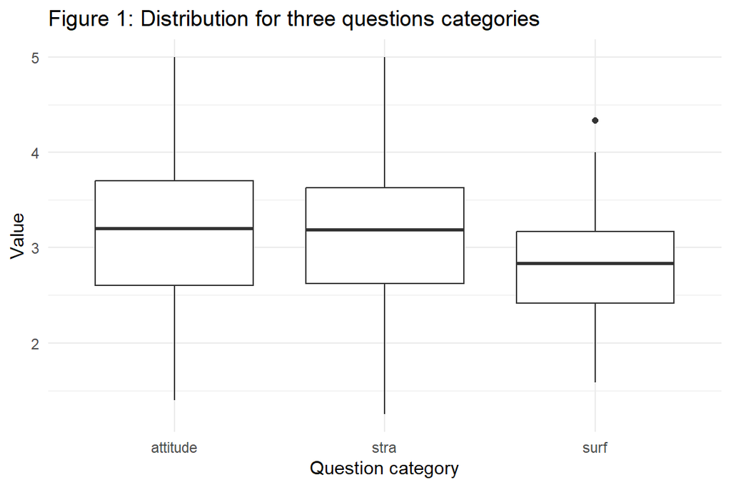

```r
ggplot(data_long, aes(x = Variable, y = value)) +
  geom_boxplot() +
  labs(title = "Figure 1: Distribution for three questions categories",
       x = "Question category",
       y = "Value") +
  theme_minimal()
```

##This figure shows the distribution for three variables. Median in these variables is around three. Next, lets look at age

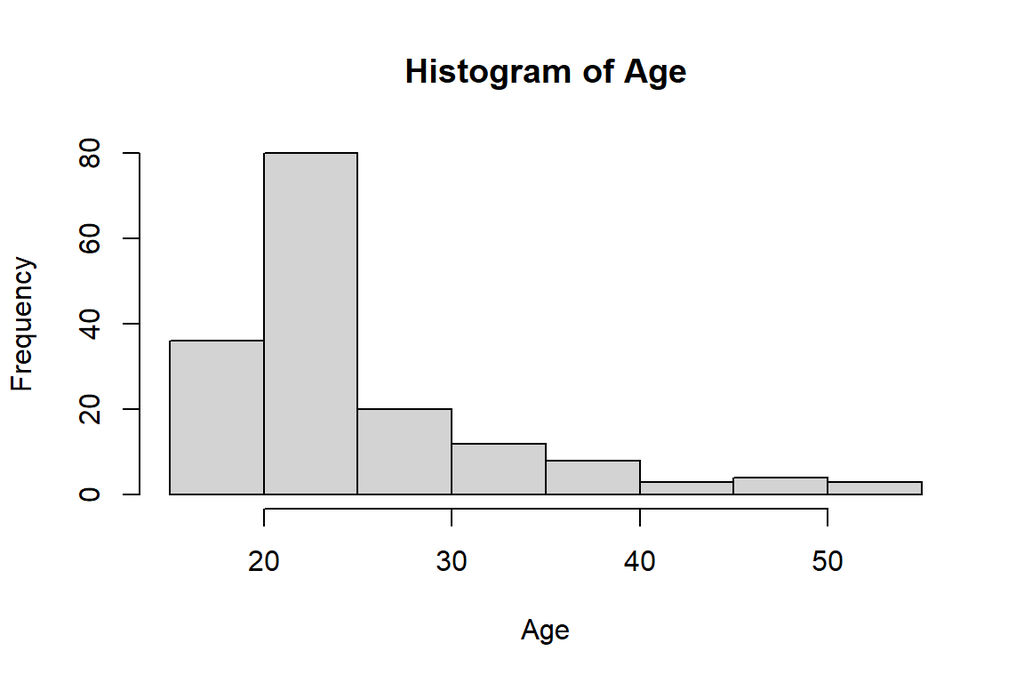

```r
  hist(analysisdata2$Age, main = "Histogram of Age", xlab = "Age", ylab = "Frequency")
```

#Next, regression

## Regression model

#Run model

```r
model <- lm(formula= Points ~ attitude + gender  + Age  + deep, data=analysisdata2)
summary(model)
```

```
##
## Call:
## lm(formula = Points ~ attitude + gender + Age + deep, data = analysisdata2)
##
## Residuals:
##      Min       1Q   Median       3Q      Max
## -17.3244  -3.3872   0.1616   3.9525  10.9188
##
## Coefficients:
##             Estimate Std. Error t value Pr(>|t|)
## (Intercept) 15.45100    3.43015   4.504 1.27e-05 ***
## attitude     3.65287    0.59677   6.121 6.83e-09 ***
## genderM     -0.31265    0.92068  -0.340    0.735
## Age         -0.07502    0.05374  -1.396    0.165
## deep        -0.59649    0.75259  -0.793    0.429
## ---
## Signif. codes:  0 '***' 0.001 '**' 0.01 '*' 0.05 '.' 0.1 ' ' 1
##
## Residual standard error: 5.321 on 161 degrees of freedom
## Multiple R-squared:  0.2049, Adjusted R-squared:  0.1851
## F-statistic: 10.37 on 4 and 161 DF,  p-value: 1.689e-07
```

T-test is used to test the significance of individual regression coefficient, it is calculated as a beta coefficient divided by standard error. T-test tells if the variable has a relatioship with the outcome in statistically meaningful way, if the coefficient is different from zero.

F-test tests if all the coefficients variable have statistically meaningful relationship (different from zero) together.

In the model above, only attitude had a statistically meaningful relatioship with points. Hence, I remove the other variables and run it again.

```r
model1 <- lm(formula= Points ~ attitude, data=analysisdata2)
summary(model1)
```

```
##
## Call:
## lm(formula = Points ~ attitude, data = analysisdata2)
##
## Residuals:
##      Min       1Q   Median       3Q      Max
## -16.9763  -3.2119   0.4339   4.1534  10.6645
##
## Coefficients:
##             Estimate Std. Error t value Pr(>|t|)
## (Intercept)  11.6372     1.8303   6.358 1.95e-09 ***
## attitude      3.5255     0.5674   6.214 4.12e-09 ***
## ---
## Signif. codes:  0 '***' 0.001 '**' 0.01 '*' 0.05 '.' 0.1 ' ' 1
##
## Residual standard error: 5.32 on 164 degrees of freedom
## Multiple R-squared:  0.1906, Adjusted R-squared:  0.1856
## F-statistic: 38.61 on 1 and 164 DF,  p-value: 4.119e-09
```

Based on outputs above one can conclude that only statistically significant coefficient in the specification is attitude (assuming homoskedastic errors!). On average one-unit increase in the scale of attitude increases points by roughly 3.5.

- t-value tests whether the coefficient is statistically significantly different from zero
- F-statistics tests whether all of the coefficient are different from zero (jointly)

##Next plots

# Residuals vs Fitted values

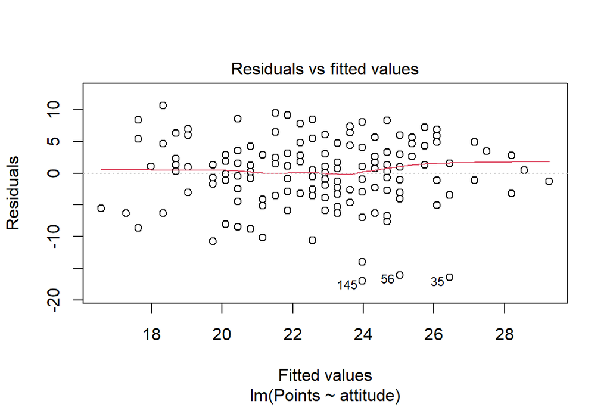

```r
plot(model1, which = 1,caption = "Residuals vs fitted values")
```

#Normal qq

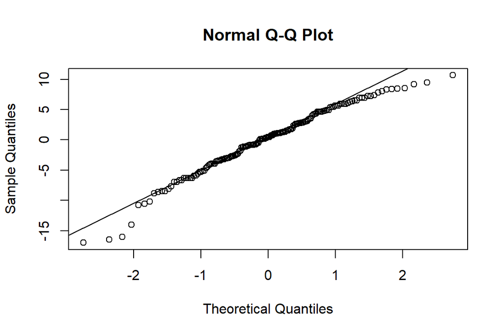

```r
qqnorm(model1$residuals)
qqline(model1$residuals)
```

#Residual vs leverage

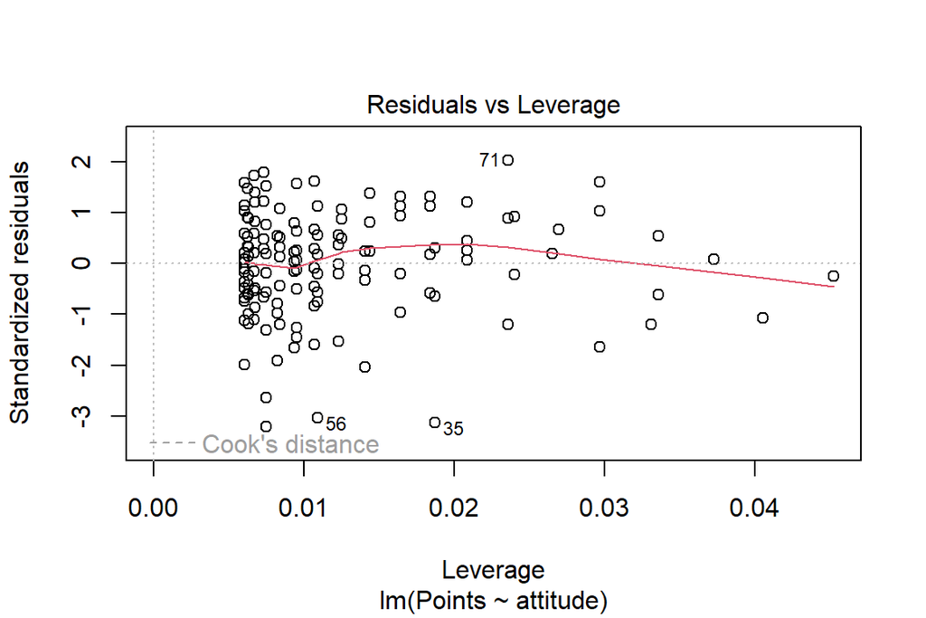

```r
plot(model1, which = 5)
```

Assumptions:

Linearity: The relationship between the independent variables and the dependent variable is linear. The model should capture a linear relationship between predictors and the outcome.

Independence of Errors (Residuals): The errors (residuals) in the model are independent of each other. There should be no correlation between consecutive residuals or any patterns in their distribution.

Homoscedasticity (Constant Variance of Errors): The variance of the errors should be constant across all levels of the independent variables. In other words, the spread of residuals should remain consistent across the range of predicted values.

Normality of Errors (Residuals): The residuals should follow a normal distribution. While the normality assumption is not necessary for unbiasedness, violations may affect the reliability of hypothesis tests and confidence interval

No Endogeneity: The independent variables are not correlated with the error term. If endogeneity exists (where a predictor is correlated with the error term), OLS estimates can be biased

##Based on the graphs linearity holds, errors might not be normally distributed but they are homoscedastic.

# 3. Logistic regression

## Read the previously created data, print it and described it briefly

```r
#Read the created data
alc <- read_csv("data/alc.csv")
names(alc)
```

```
##  [1] "school"     "sex"        "age"        "address"    "famsize"
##  [6] "Pstatus"    "Medu"       "Fedu"       "Mjob"       "Fjob"
## [11] "reason"     "guardian"   "traveltime" "studytime"  "schoolsup"
## [16] "famsup"     "activities" "nursery"    "higher"     "internet"
## [21] "romantic"   "famrel"     "freetime"   "goout"      "Dalc"
## [26] "Walc"       "health"     "failures"   "paid"       "absences"
## [31] "G1"         "G2"         "G3"         "alc_use"    "high_use"
```

#This data set includes information about student achievement in secondary education from two Portuguese schools. Two datasets are combined, including performance info from two different subject: math and Portuguese. Detailed information of variables in the data sets can be seen below: # Attributes for both student-mat.csv (Math course) and student-por.csv (Portuguese language course) datasets:

1 school - student’s school (binary: ‘GP’ - Gabriel Pereira or ‘MS’ - Mousinho da Silveira)

2 sex - student’s sex (binary: ‘F’ - female or ‘M’ - male)

3 age - student’s age (numeric: from 15 to 22)

4 address - student’s home address type (binary: ‘U’ - urban or ‘R’ - rural)

5 famsize - family size (binary: ‘LE3’ - less or equal to 3 or ‘GT3’ - greater than 3)

6 Pstatus - parent’s cohabitation status (binary: ‘T’ - living together or ‘A’ - apart)

7 Medu - mother’s education (numeric: 0 - none, 1 - primary education (4th grade), 2 – 5th to 9th grade, 3 – secondary education or 4 – higher education)

8 Fedu - father’s education (numeric: 0 - none, 1 - primary education (4th grade), 2 – 5th to 9th grade, 3 – secondary education or 4 – higher education)

9 Mjob - mother’s job (nominal: ‘teacher’, ‘health’ care related, civil ‘services’ (e.g. administrative or police), ‘at_home’ or ‘other’)

10 Fjob - father’s job (nominal: ‘teacher’, ‘health’ care related, civil ‘services’ (e.g. administrative or police), ‘at_home’ or ‘other’)

11 reason - reason to choose this school (nominal: close to ‘home’, school ‘reputation’, ‘course’ preference or ‘other’)

12 guardian - student’s guardian (nominal: ‘mother’, ‘father’ or ‘other’)

13 traveltime - home to school travel time (numeric: 1 - <15 min., 2 - 15 to 30 min., 3 - 30 min. to 1 hour, or 4 - >1 hour)

14 studytime - weekly study time (numeric: 1 - <2 hours, 2 - 2 to 5 hours, 3 - 5 to 10 hours, or 4 - >10 hours)

15 failures - number of past class failures (numeric: n if 1<=n<3, else 4)

16 schoolsup - extra educational support (binary: yes or no)

17 famsup - family educational support (binary: yes or no)

18 paid - extra paid classes within the course subject (Math or Portuguese) (binary: yes or no)

19 activities - extra-curricular activities (binary: yes or no)

20 nursery - attended nursery school (binary: yes or no)

21 higher - wants to take higher education (binary: yes or no)

22 internet - Internet access at home (binary: yes or no)

23 romantic - with a romantic relationship (binary: yes or no)

24 famrel - quality of family relationships (numeric: from 1 - very bad to 5 - excellent)

25 freetime - free time after school (numeric: from 1 - very low to 5 - very high)

26 goout - going out with friends (numeric: from 1 - very low to 5 - very high)

27 Dalc - workday alcohol consumption (numeric: from 1 - very low to 5 - very high)

28 Walc - weekend alcohol consumption (numeric: from 1 - very low to 5 - very high)

29 health - current health status (numeric: from 1 - very bad to 5 - very good)

30 absences - number of school absences (numeric: from 0 to 93)

#these grades are related with the course subject, Math or Portuguese:

31 G1 - first period grade (numeric: from 0 to 20)

31 G2 - second period grade (numeric: from 0 to 20)

32 G3 - final grade (numeric: from 0 to 20, output target

# To study the relationship between high/low alcohol consumption I choose the following variables. Mother’s education, activities, weekly study time and going out with friends.

My personal hypothesis regarding my chosen variables are the following:

Mother’s education, activities and weekly study time are negatively correlated with alcohol consumption i.e the higher the value of these variables are the lower alcohol consumption is.

Going out with friends is probably positively correlated with alcohol consumption.

# Let’s draw some graphs, first mother’s education

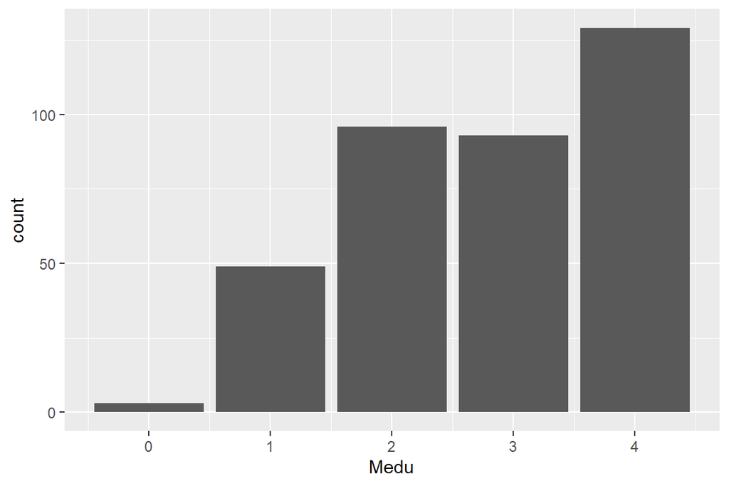

```r
#
g2 <- ggplot(data = alc, aes(x = Medu))

# define the plot as a bar plot and draw it
g2 + geom_bar()
```

```r
##cross tab

table(Medu = alc$Medu)
```

```
## Medu
##   0   1   2   3   4
##   3  49  96  93 129
```

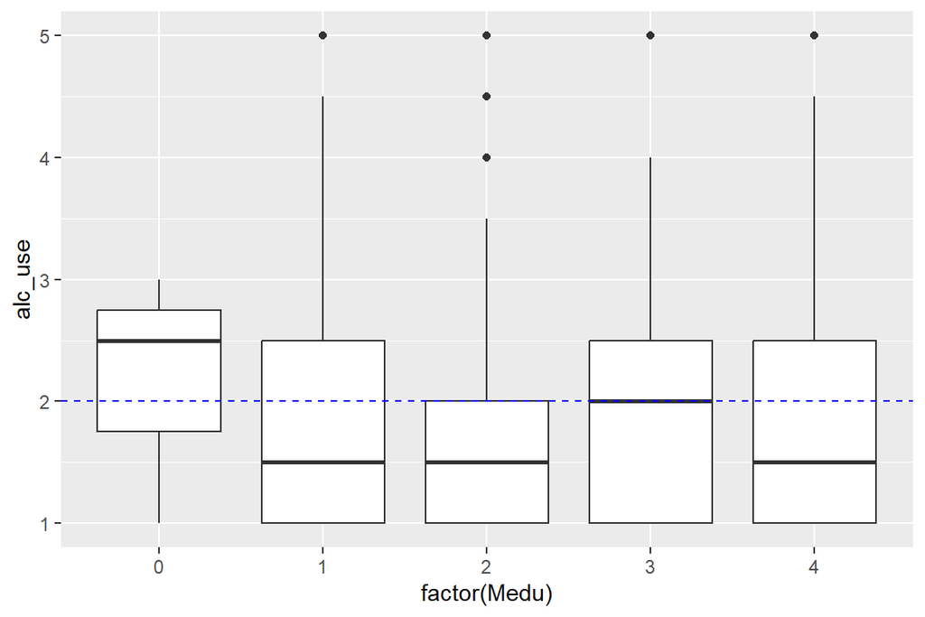

```r
#
g1 <- ggplot(data=alc, aes(x=factor(Medu),y=alc_use))

# define the plot as a boxplot and draw it
g1 +  geom_boxplot()+
  geom_hline(yintercept = 2,linetype="dashed", color="blue")
```

```r
  labs(y="Alcohol cons", x="Mother's education", title = "Alcohol consumption and mothers education")
```

```
## $y
## [1] "Alcohol cons"
##
## $x
## [1] "Mother's education"
##
## $title
## [1] "Alcohol consumption and mothers education"
##
## attr(,"class")
## [1] "labels"
```

## Next variable, acitivites

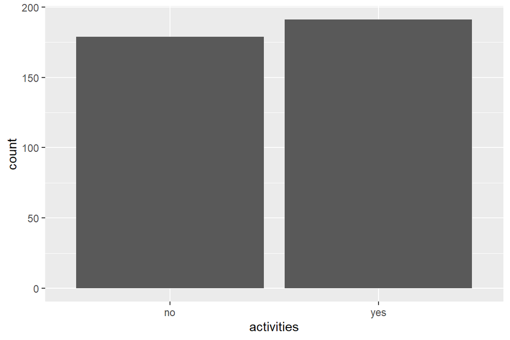

```r
#
g3 <- ggplot(data = alc, aes(x = activities))

# define the plot as a bar plot and draw it
g3 + geom_bar()
```

```r
#tabyl(alc$activities)
table(activities = alc$activities)
```

```
## activities
##  no yes
## 179 191
```

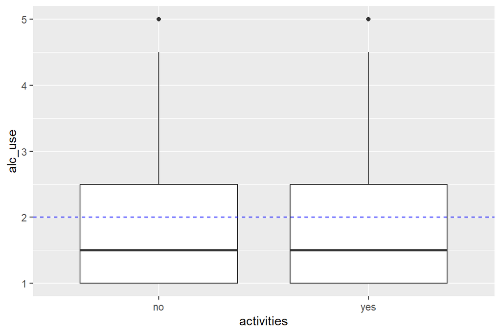

```r
#
g4 <- ggplot(data=alc, aes(x=activities,y=alc_use))

# define the plot as a boxplot and draw it
g4 +  geom_boxplot()+
  geom_hline(yintercept = 2,linetype="dashed", color="blue")
```

```r
  labs(y="Alcohol cons", x="activities", title = "Alcohol consumption and activities")
```

```
## $y
## [1] "Alcohol cons"
##
## $x
## [1] "activities"
##
## $title
## [1] "Alcohol consumption and activities"
##
## attr(,"class")
## [1] "labels"
```

##It seems that activities is almost equally distributed between yes and no. There are slightly more yes answers (51%). Surprisingly, extra activities are not related to drinking, based on the graph. My hypothesis was wrong (again), damn it.

## Next one, weekly study time

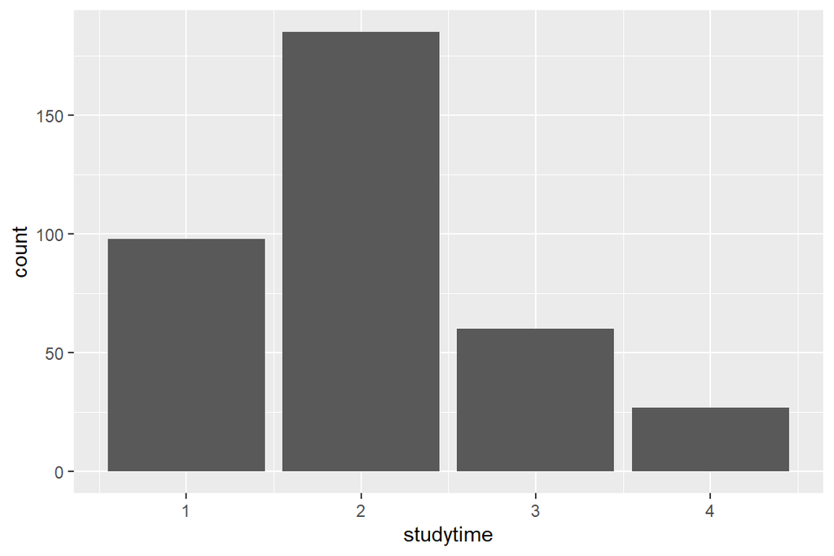

```r
#
g5 <- ggplot(data = alc, aes(x = studytime))

# define the plot as a bar plot and draw it
g5 + geom_bar()
```

```r
#tabyl(alc$studytime)
table(studytime = alc$studytime)
```

```
## studytime
##   1   2   3   4
##  98 185  60  27
```

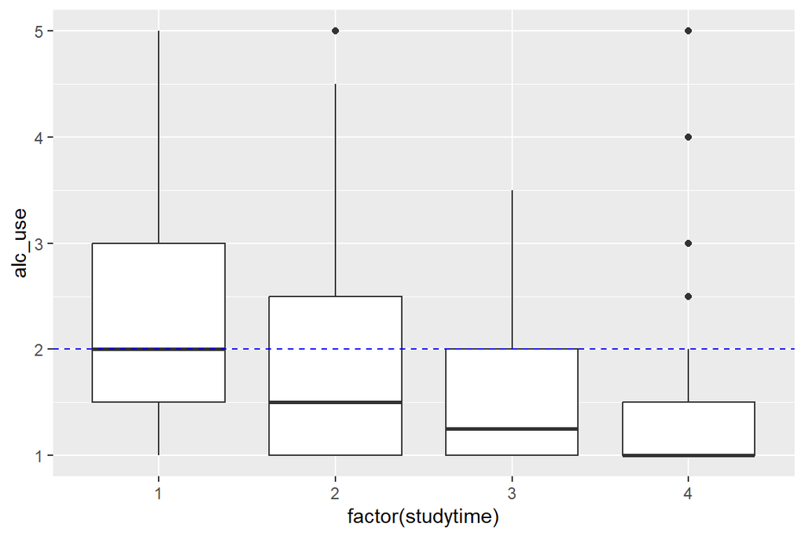

```r
#
g6 <- ggplot(data=alc, aes(x=factor(studytime),y=alc_use))

# define the plot as a boxplot and draw it
g6 +  geom_boxplot()+
  geom_hline(yintercept = 2,linetype="dashed", color="blue")
```

```r
  labs(y="Alcohol cons", x="studytime", title = "Alcohol consumption and studytime")
```

```
## $y
## [1] "Alcohol cons"
##
## $x
## [1] "studytime"
##
## $title
## [1] "Alcohol consumption and studytime"
##
## attr(,"class")
## [1] "labels"
```

Most common study time seems to be between 2-5 hours and only a small fraction studies more than ten hours in a week. Alcohol consumption decreases when study time increases, so I my hypothesis was on the right track. Vamos!

## Next one, going out with friends

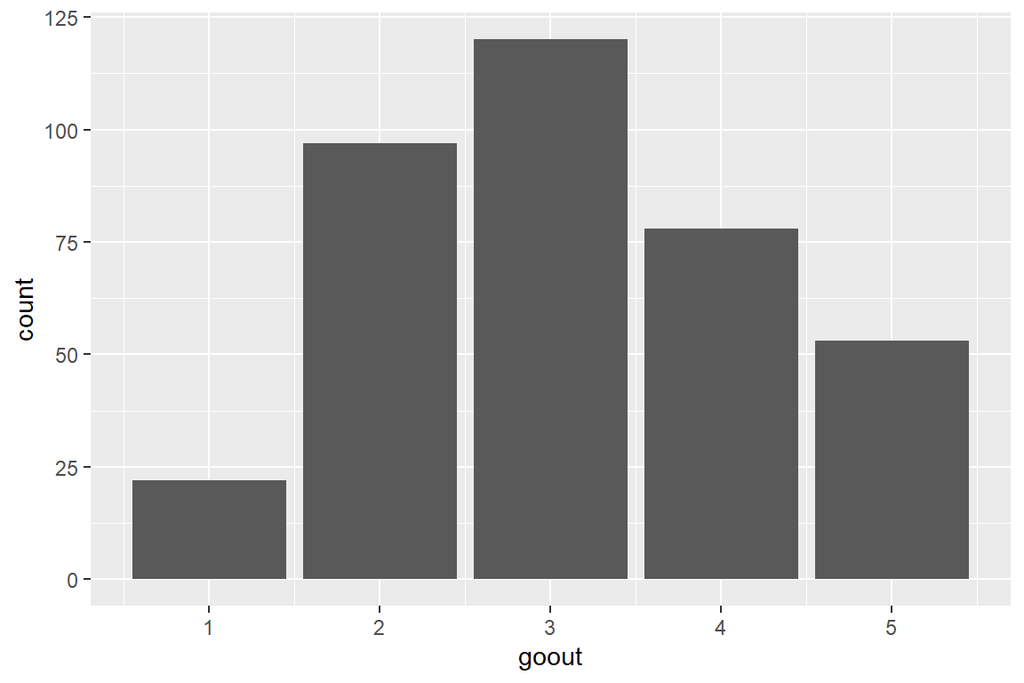

```r
#
g7 <- ggplot(data = alc, aes(x = goout))

# define the plot as a bar plot and draw it
g7 + geom_bar()
```

```r
#tabyl(alc$goout)
table(goout = alc$goout)
```

```
## goout
##   1   2   3   4   5
##  22  97 120  78  53
```

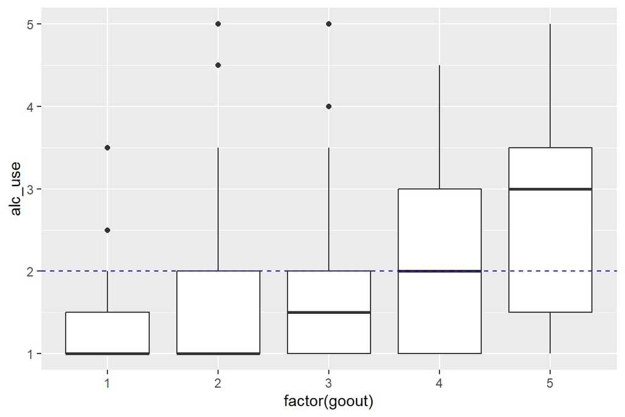

```r
#
g8 <- ggplot(data=alc, aes(x=factor(goout),y=alc_use))

# define the plot as a boxplot and draw it
g8 +  geom_boxplot()+
  geom_hline(yintercept = 2,linetype="dashed", color="blue")
```

```r
  labs(y="Alcohol cons", x="goout", title = "Alcohol consumption and studytime")
```

```
## $y
## [1] "Alcohol cons"
##
## $x
## [1] "goout"
##
## $title
## [1] "Alcohol consumption and studytime"
##
## attr(,"class")
## [1] "labels"
```

Going out variable looks almost like a normally distributed, where three is the most common and extremes are rare (1 and 5). As guessesd, alcohol consumption increases with going out.

## Logistic regression

### Estimating the model

```r
model <- glm(high_use ~ Medu + activities + studytime + goout ,family=binomial,data=alc)
summary(model)
```

```
##
## Call:
## glm(formula = high_use ~ Medu + activities + studytime + goout,
##     family = binomial, data = alc)
##
## Coefficients:
##               Estimate Std. Error z value Pr(>|z|)
## (Intercept)   -1.93014    0.58334  -3.309 0.000937 ***
## Medu          -0.02342    0.11586  -0.202 0.839797
## activitiesyes -0.27897    0.25352  -1.100 0.271175
## studytime     -0.60317    0.16676  -3.617 0.000298 ***
## goout          0.75204    0.11833   6.356 2.08e-10 ***
## ---
## Signif. codes:  0 '***' 0.001 '**' 0.01 '*' 0.05 '.' 0.1 ' ' 1
##
## (Dispersion parameter for binomial family taken to be 1)
##
##     Null deviance: 452.04  on 369  degrees of freedom
## Residual deviance: 386.08  on 365  degrees of freedom
## AIC: 396.08
##
## Number of Fisher Scoring iterations: 4
```

```r
# compute odds ratios (OR)
OR <- coef(model) %>% exp

# compute confidence intervals (CI)
CI <- confint(model)%>% exp
# print out the odds ratios with their confidence intervals
cbind(OR, CI)
```

```
##                      OR      2.5 %    97.5 %
## (Intercept)   0.1451285 0.04494928 0.4453251
## Medu          0.9768512 0.77844116 1.2273048
## activitiesyes 0.7565664 0.45904580 1.2427009
## studytime     0.5470748 0.39008351 0.7514344
## goout         2.1213203 1.69265953 2.6944645
```

Looking at the odd ratios and confidence intervals, I can tell that from my chosen variables, only study time and going out are statistically significant (does not include 1). The OR ratio tells the odds that outcome happened in presence of exposure compared to odds that the outcome happened in absence of that same exposure. OR=1 means that the predictor does not have connection with the outcome, OR<1 means that odds of the outcome happening is lower compared to the reference level and if OR>1 then odds of the outcome happening is higher for the predictor compared to reference point.

Only OR>1 is going out, with odd-ratio 2.12. This means that odds of using alchol is 2.12 times higher when going out increases by one. For the other predictors OR<1, meaning that the odds for alcohol consumption are smaller when predictor increases.

### Prediction vs. actual

```r
#include only predictors with statistical significance
model1 <- glm(high_use ~  studytime + goout ,family=binomial,data=alc)

# predict() the probability of high_use
alc <- mutate(alc, probability = predict(model1, type = "response"))

# use the probabilities to make a prediction of high_use
alc <- mutate(alc, prediction = probability > 0.5)

# tabulate the target variable versus the predictions
#tabyl(alc, high_use,prediction)

table(high_use = alc$high_use, prediction = alc$prediction)
```

```
##         prediction
## high_use FALSE TRUE
##    FALSE   238   21
##    TRUE     70   41
```

### The total proportion of inaccurately classified individuals

```r
inaccurate <- nrow(alc %>% filter(high_use!=prediction))
all <- nrow(alc)

inaccurate/all
```

```
## [1] 0.2459459
```

The proportion of inaccurately classified indidiuals is 24,5%. My model predicts the correct outcome with desent accuracy.

## Simple guessing strategy

```r
#include only predictors with statistical significance
model2 <- glm(high_use ~  school + sex +age ,family=binomial,data=alc)

# predict() the probability of high_use
alc <- mutate(alc, probability2 = predict(model2, type = "response"))

# use the probabilities to make a prediction of high_use
alc <- mutate(alc, prediction2 = probability2 > 0.5)

# tabulate the target variable versus the predictions
#tabyl(alc, high_use,prediction)

table(high_use = alc$high_use, prediction = alc$prediction2)
```

```
##         prediction
## high_use FALSE TRUE
##    FALSE   254    5
##    TRUE    108    3
```

```r
inaccurate2 <- nrow(alc %>% filter(high_use!=prediction2))
all2 <- nrow(alc)

inaccurate2/all2
```

```
## [1] 0.3054054
```

With simple guessing strategy the share of inaccurate guesses is 30%

# Bonus

```r
# define a loss function (average prediction error)
loss_func <- function(class, prob) {
  n_wrong <- abs(class - prob) > 0.5
  mean(n_wrong)
}

# compute the average number of wrong predictions in the (training) data


# K-fold cross-validation
library(boot)
cv <- cv.glm(data = alc, cost = loss_func, glmfit = model2, K = nrow(alc))

# average number of wrong predictions in the cross validation
cv$delta[1]
```

```
## [1] 0.3135135
```

The model in exercise set was better. My error here is bigger.

# 4. Clustering and classification

## Let’s load the data and describe it

```r
data(Boston)
str(Boston)
```

```
## 'data.frame':    506 obs. of  14 variables:
##  $ crim   : num  0.00632 0.02731 0.02729 0.03237 0.06905 ...
##  $ zn     : num  18 0 0 0 0 0 12.5 12.5 12.5 12.5 ...
##  $ indus  : num  2.31 7.07 7.07 2.18 2.18 2.18 7.87 7.87 7.87 7.87 ...
##  $ chas   : int  0 0 0 0 0 0 0 0 0 0 ...
##  $ nox    : num  0.538 0.469 0.469 0.458 0.458 0.458 0.524 0.524 0.524 0.524 ...
##  $ rm     : num  6.58 6.42 7.18 7 7.15 ...
##  $ age    : num  65.2 78.9 61.1 45.8 54.2 58.7 66.6 96.1 100 85.9 ...
##  $ dis    : num  4.09 4.97 4.97 6.06 6.06 ...
##  $ rad    : int  1 2 2 3 3 3 5 5 5 5 ...
##  $ tax    : num  296 242 242 222 222 222 311 311 311 311 ...
##  $ ptratio: num  15.3 17.8 17.8 18.7 18.7 18.7 15.2 15.2 15.2 15.2 ...
##  $ black  : num  397 397 393 395 397 ...
##  $ lstat  : num  4.98 9.14 4.03 2.94 5.33 ...
##  $ medv   : num  24 21.6 34.7 33.4 36.2 28.7 22.9 27.1 16.5 18.9 ...
```

Housing values in Suburbs of Boston gives info on houses and areas in Boston. See full description of the variables below:

Description

The Boston data frame has 506 rows and 14 columns. Usage

Boston

Format

This data frame contains the following columns:

crim

```
per capita crime rate by town.
```

zn

```
proportion of residential land zoned for lots over 25,000 sq.ft.
```

indus

```
proportion of non-retail business acres per town.
```

chas

```
Charles River dummy variable (= 1 if tract bounds river; 0 otherwise).
```

nox

```
nitrogen oxides concentration (parts per 10 million).
```

rm

```
average number of rooms per dwelling.
```

age

```
proportion of owner-occupied units built prior to 1940.
```

dis

```
weighted mean of distances to five Boston employment centres.
```

rad

```
index of accessibility to radial highways.
```

tax

```
full-value property-tax rate per $10,000.
```

ptratio

```
pupil-teacher ratio by town.
```

black

[output not shown]

lstat

```
lower status of the population (percent).
```

medv

```
median value of owner-occupied homes in $1000s.
```

Source

Harrison, D. and Rubinfeld, D.L. (1978) Hedonic prices and the demand for clean air. J. Environ. Economics and Management 5, 81–102.

Belsley D.A., Kuh, E. and Welsch, R.E. (1980) Regression Diagnostics. Identifying Influential Data and Sources of Collinearity. New York: Wiley.

## Graphical overview

### First, I’ll plot the distributions. Before that, I’ll reshape the data from wide to long.

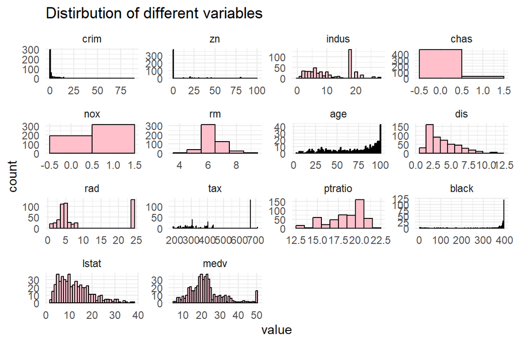

```r
library(reshape2)

# Melt the dataset
long_data <- melt(Boston)

# Plot the distributions
ggplot(long_data, aes(x = value)) +
  geom_histogram(binwidth = 1, fill = "pink", color = "black") +
  facet_wrap(~variable, scales = "free") +
  theme_minimal()+
  labs(title="Distirbution of different variables")
```

Looking at the distributions one can see that crim, zn, age dis and rad are skewed